# Project: Insurance Policy Cancellation

# Feature Engineering

## Label Encoding

Since at a later stage, we intend to use MinMax Scaler, we need to make sure that each feature contains only numeric data. So we use LabelEncoder to convert object type to numeric type.

```python
# Let us check the data types before LabelEncoding
X_train.info()
```

```
<class 'pandas.core.frame.DataFrame'>
Int64Index: 699915 entries, 0 to 700231
Data columns (total 16 columns):
 #   Column             Non-Null Count   Dtype
---  ------             --------------   -----
 0   year               699915 non-null  int64
 1   zip.code           699915 non-null  float64
 2   house.color        699915 non-null  object
 3   ni.age             699915 non-null  float64
 4   len.at.res         699915 non-null  float64
 5   credit             699915 non-null  object
 6   coverage.type      699915 non-null  object
 7   dwelling.type      699915 non-null  object
 8   premium            699915 non-null  float64
 9   sales.channel      699915 non-null  object
 10  ni.gender          699915 non-null  object
 11  ni.marital.status  699915 non-null  float64
 12  n.adults           699915 non-null  float64
 13  n.children         699915 non-null  float64
 14  tenure             699915 non-null  float64
 15  claim.ind          699915 non-null  float64
dtypes: float64(9), int64(1), object(6)
memory usage: 106.9+ MB
```

```python
X_test.info()
```

```
<class 'pandas.core.frame.DataFrame'>
RangeIndex: 344891 entries, 0 to 344890
Data columns (total 16 columns):
 #   Column             Non-Null Count   Dtype
---  ------             --------------   -----
 0   year               344891 non-null  int64
 1   zip.code           344891 non-null  float64
 2   house.color        344891 non-null  object
 3   ni.age             344891 non-null  float64
 4   len.at.res         344891 non-null  float64
 5   credit             344891 non-null  object
 6   coverage.type      344891 non-null  object
 7   dwelling.type      344891 non-null  object
 8   premium            344891 non-null  float64
 9   sales.channel      344891 non-null  object
 10  ni.gender          344891 non-null  object
 11  ni.marital.status  344891 non-null  float64
 12  n.adults           344891 non-null  float64
 13  n.children         344891 non-null  float64
 14  tenure             344891 non-null  float64
 15  claim.ind          344891 non-null  float64
dtypes: float64(9), int64(1), object(6)
memory usage: 42.1+ MB
```

Since **MinMax Scaler** requires us to provide all numeric columns, we use LabelEncoder for categorical variables to convert them to numerical.

```python
Le = LabelEncoder()
for column in ['ni.gender','coverage.type', 'dwelling.type', 'sales.channel', 'credit', 'house.color']:
  X_train[column] = Le.fit_transform(X_train[column])
  X_test[column] = Le.transform(X_test[column])
X_test.head()
```

|  | year | zip.code | house.color | ni.age | len.at.res | credit | coverage.type | dwelling.type | premium | sales.channel | ni.gender | ni.marital.status | n.adults | n.children | tenure | claim.ind |
| --- | --- | --- | --- | --- | --- | --- | --- | --- | --- | --- | --- | --- | --- | --- | --- | --- |
| 0 | 2013 | 50020.0 | 2 | 33.0 | 16.0 | 0 | 2 | 1 | 796.385532 | 0 | 0 | 1.0 | 1.0 | 3.0 | 2.0 | 1.0 |
| 1 | 2013 | 80002.0 | 1 | 56.0 | 10.0 | 0 | 0 | 1 | 773.232687 | 0 | 1 | 1.0 | 2.0 | 0.0 | 14.0 | 0.0 |
| 2 | 2015 | 85005.0 | 2 | 46.0 | 12.0 | 0 | 2 | 0 | 943.047142 | 0 | 0 | 1.0 | 2.0 | 2.0 | 9.0 | 0.0 |
| 3 | 2015 | 98026.0 | 0 | 45.0 | 15.0 | 0 | 0 | 2 | 949.368847 | 0 | 1 | 1.0 | 1.0 | 3.0 | 12.0 | 0.0 |
| 4 | 2014 | 50022.0 | 2 | 28.0 | 19.0 | 1 | 2 | 2 | 875.873613 | 0 | 0 | 1.0 | 1.0 | 1.0 | 7.0 | 1.0 |

```python
#Let us check the data types After LabelEncoding
X_train.info()
#We can observe that all the datatypes get converted to numerical(int64, float64)
```

```
<class 'pandas.core.frame.DataFrame'>
Int64Index: 699915 entries, 0 to 700231
Data columns (total 16 columns):
 #   Column             Non-Null Count   Dtype
---  ------             --------------   -----
 0   year               699915 non-null  int64
 1   zip.code           699915 non-null  float64
 2   house.color        699915 non-null  int32
 3   ni.age             699915 non-null  float64
 4   len.at.res         699915 non-null  float64
 5   credit             699915 non-null  int32
 6   coverage.type      699915 non-null  int32
 7   dwelling.type      699915 non-null  int32
 8   premium            699915 non-null  float64
 9   sales.channel      699915 non-null  int32
 10  ni.gender          699915 non-null  int32
 11  ni.marital.status  699915 non-null  float64
 12  n.adults           699915 non-null  float64
 13  n.children         699915 non-null  float64
 14  tenure             699915 non-null  float64
 15  claim.ind          699915 non-null  float64
dtypes: float64(9), int32(6), int64(1)
memory usage: 90.9 MB
```

```python
X_test.info()
```

```
<class 'pandas.core.frame.DataFrame'>
RangeIndex: 344891 entries, 0 to 344890
Data columns (total 16 columns):
 #   Column             Non-Null Count   Dtype
---  ------             --------------   -----
 0   year               344891 non-null  int64
 1   zip.code           344891 non-null  float64
 2   house.color        344891 non-null  int32
 3   ni.age             344891 non-null  float64
 4   len.at.res         344891 non-null  float64
 5   credit             344891 non-null  int32
 6   coverage.type      344891 non-null  int32
 7   dwelling.type      344891 non-null  int32
 8   premium            344891 non-null  float64
 9   sales.channel      344891 non-null  int32
 10  ni.gender          344891 non-null  int32
 11  ni.marital.status  344891 non-null  float64
 12  n.adults           344891 non-null  float64
 13  n.children         344891 non-null  float64
 14  tenure             344891 non-null  float64
 15  claim.ind          344891 non-null  float64
dtypes: float64(9), int32(6), int64(1)
memory usage: 34.2 MB
```

## MinMaxScaler

### Statistics before MinMaxScaler

```python
print(X_train.describe())

#we can observe that the max and min values doesnot confine to the range [0-1].
#Since the model training is all about finding weights for each feature ideally we want the range of features to fall in a certain range, here [0-1]
#Therefore we are using MinMax scaler to scale values to reflect range [0-1] for all features.
```

```
                year       zip.code    house.color         ni.age  \
count  699915.000000  699915.000000  699915.000000  699915.000000
mean     2014.630104   62383.157415       1.280238      43.488016
std         1.111723   27971.683264       0.970027      11.783507
min      2013.000000   15001.000000       0.000000      18.000000
25%      2014.000000   50009.000000       0.000000      35.000000
50%      2015.000000   80011.000000       1.000000      43.000000
75%      2016.000000   85030.000000       2.000000      51.000000
max      2016.000000   98038.000000       3.000000     130.000000

          len.at.res         credit  coverage.type  dwelling.type  \
count  699915.000000  699915.000000  699915.000000  699915.000000
mean       15.215750       0.599689       1.080035       0.958546
std         4.564193       0.822320       0.868270       0.660801
min         1.000000       0.000000       0.000000       0.000000
25%        12.000000       0.000000       0.000000       1.000000
50%        15.000000       0.000000       1.000000       1.000000
75%        18.000000       1.000000       2.000000       1.000000
max        49.997586       2.000000       2.000000       2.000000

             premium  sales.channel      ni.gender  ni.marital.status  \
count  699915.000000  699915.000000  699915.000000      699915.000000
mean      899.981040       0.751976       0.520780           0.710886
std        77.598368       0.923983       0.499568           0.453351
min       612.389520       0.000000       0.000000           0.000000
25%       844.074867       0.000000       0.000000           0.000000
50%       899.911346       0.000000       1.000000           1.000000
75%       955.404084       2.000000       1.000000           1.000000
max      1235.480942       2.000000       1.000000           1.000000

            n.adults     n.children         tenure      claim.ind
count  699915.000000  699915.000000  699915.000000  699915.000000
mean        2.132832       1.738369      11.679750       0.198951
std         1.253120       2.340697       5.931083       0.399212
min         1.000000       0.000000       0.000000       0.000000
25%         1.000000       0.000000       6.000000       0.000000
50%         2.000000       1.000000      13.000000       0.000000
75%         3.000000       2.000000      16.000000       0.000000
max        12.000000      12.000000      33.000000       1.000000
```

```python
scaler = MinMaxScaler()
X_train[X_train.columns] = scaler.fit_transform(X_train[X_train.columns])
```

### Statistics after MinMaxScaler

```python
X_train.describe()

#Here we can observe that values has been scaled to the range [0-1]
```

|  | year | zip.code | house.color | ni.age | len.at.res | credit | coverage.type | dwelling.type | premium | sales.channel | ni.gender | ni.marital.status | n.adults | n.children | tenure | claim.ind |
| --- | --- | --- | --- | --- | --- | --- | --- | --- | --- | --- | --- | --- | --- | --- | --- | --- |
| count | 699915.000000 | 699915.000000 | 699915.000000 | 699915.000000 | 699915.000000 | 699915.000000 | 699915.000000 | 699915.000000 | 699915.000000 | 699915.000000 | 699915.000000 | 699915.000000 | 699915.000000 | 699915.000000 | 699915.000000 | 699915.000000 |
| mean | 0.543368 | 0.570615 | 0.426746 | 0.227572 | 0.290132 | 0.299844 | 0.540018 | 0.479273 | 0.461556 | 0.375988 | 0.520780 | 0.710886 | 0.102985 | 0.144864 | 0.353932 | 0.198951 |
| std | 0.370574 | 0.336858 | 0.323342 | 0.105210 | 0.093151 | 0.411160 | 0.434135 | 0.330401 | 0.124538 | 0.461992 | 0.499568 | 0.453351 | 0.113920 | 0.195058 | 0.179730 | 0.399212 |
| min | 0.000000 | 0.000000 | 0.000000 | 0.000000 | 0.000000 | 0.000000 | 0.000000 | 0.000000 | 0.000000 | 0.000000 | 0.000000 | 0.000000 | 0.000000 | 0.000000 | 0.000000 | 0.000000 |
| 25% | 0.333333 | 0.421595 | 0.000000 | 0.151786 | 0.224501 | 0.000000 | 0.000000 | 0.500000 | 0.371832 | 0.000000 | 0.000000 | 0.000000 | 0.000000 | 0.000000 | 0.181818 | 0.000000 |
| 50% | 0.666667 | 0.782904 | 0.333333 | 0.223214 | 0.285728 | 0.000000 | 0.500000 | 0.500000 | 0.461444 | 0.000000 | 1.000000 | 1.000000 | 0.090909 | 0.083333 | 0.393939 | 0.000000 |
| 75% | 1.000000 | 0.843347 | 0.666667 | 0.294643 | 0.346956 | 0.500000 | 1.000000 | 0.500000 | 0.550504 | 1.000000 | 1.000000 | 1.000000 | 0.181818 | 0.166667 | 0.484848 | 0.000000 |
| max | 1.000000 | 1.000000 | 1.000000 | 1.000000 | 1.000000 | 1.000000 | 1.000000 | 1.000000 | 1.000000 | 1.000000 | 1.000000 | 1.000000 | 1.000000 | 1.000000 | 1.000000 | 1.000000 |

```python
# X_test.drop("cancel", axis=1, inplace=True)
X_test[X_test.columns] = scaler.transform(X_test[X_test.columns])
X_test.describe()
```

|  | year | zip.code | house.color | ni.age | len.at.res | credit | coverage.type | dwelling.type | premium | sales.channel | ni.gender | ni.marital.status | n.adults | n.children | tenure | claim.ind |
| --- | --- | --- | --- | --- | --- | --- | --- | --- | --- | --- | --- | --- | --- | --- | --- | --- |
| count | 344891.000000 | 344891.000000 | 344891.000000 | 344891.000000 | 344891.000000 | 344891.000000 | 344891.000000 | 344891.000000 | 344891.000000 | 344891.000000 | 344891.000000 | 344891.000000 | 344891.000000 | 344891.000000 | 344891.000000 | 344891.000000 |
| mean | 0.543376 | 0.569407 | 0.427372 | 0.228266 | 0.290106 | 0.299748 | 0.539871 | 0.477889 | 0.461208 | 0.375942 | 0.521086 | 0.708714 | 0.103005 | 0.144523 | 0.353640 | 0.200307 |
| std | 0.369988 | 0.337628 | 0.323896 | 0.110406 | 0.093156 | 0.410915 | 0.434112 | 0.330434 | 0.124875 | 0.461812 | 0.499556 | 0.454356 | 0.114131 | 0.195187 | 0.179681 | 0.400230 |
| min | 0.000000 | 0.000000 | 0.000000 | 0.000000 | 0.000000 | 0.000000 | 0.000000 | 0.000000 | 0.010198 | 0.000000 | 0.000000 | 0.000000 | 0.000000 | 0.000000 | 0.000000 | 0.000000 |
| 25% | 0.333333 | 0.421595 | 0.000000 | 0.151786 | 0.224501 | 0.000000 | 0.000000 | 0.500000 | 0.371529 | 0.000000 | 0.000000 | 0.000000 | 0.000000 | 0.000000 | 0.181818 | 0.000000 |
| 50% | 0.666667 | 0.782904 | 0.333333 | 0.223214 | 0.285728 | 0.000000 | 0.500000 | 0.500000 | 0.460966 | 0.000000 | 1.000000 | 1.000000 | 0.090909 | 0.083333 | 0.393939 | 0.000000 |
| 75% | 1.000000 | 0.843347 | 0.666667 | 0.294643 | 0.346956 | 0.500000 | 1.000000 | 0.500000 | 0.550207 | 1.000000 | 1.000000 | 1.000000 | 0.181818 | 0.166667 | 0.484848 | 0.000000 |
| max | 1.000000 | 1.000000 | 1.000000 | 3.432151 | 1.000019 | 1.000000 | 1.000000 | 1.000000 | 1.012566 | 1.000000 | 1.000000 | 1.000000 | 1.000000 | 1.000000 | 1.030303 | 1.000000 |

# Sampling

```python
Counter(y_train['cancel'])
```

```
Counter({0: 496238, 2: 153175, 1: 50502})
```

```python
# from imblearn.over_sampling import SMOTE

# sampler = SMOTE(k_neighbors=3)

# X_sampled, y_sampled = sampler.fit_resample(X_train, y_train)
```

```python
# define oversampling strategy
oversample = RandomOverSampler(sampling_strategy='minority')
# fit and apply the transform
X_sampled, y_sampled = oversample.fit_resample(X_train, y_train)
# summarize class distribution
print(Counter(y_sampled['cancel']))
```

```
Counter({0: 496238, 1: 496238, 2: 153175})
```

# Modelling

```python
DTC1 = DecisionTreeClassifier(max_depth=5, min_samples_split=30)
DTC2 = DecisionTreeClassifier()
RFC = RandomForestClassifier()
GBC = GradientBoostingClassifier()
BC = BaggingClassifier()
LRC = LogisticRegression()
NNC = MLPClassifier()
ABC = AdaBoostClassifier(learning_rate=0.01)
ETC = ExtraTreesClassifier()
GNC = GaussianNB()
KNC = KNeighborsClassifier()
```

```python
model = RFC
model.fit(X_sampled, y_sampled)
train_preds = model.predict(X_sampled)
test_preds = model.predict(X_test)
```

# Model Results

```python
print("Training Accuracy and Performance Metrics")
print(classification_report(y_sampled, train_preds))

print("Confusion matrix for Training data")
print(confusion_matrix(y_sampled, train_preds))

print("Test Accuracy and Performance Metrics")
print(classification_report(y_test, test_preds))

print("Confusion matrix for Testing data")
print(confusion_matrix(y_test, test_preds))
```

```
Training Accuracy and Performance Metrics
              precision    recall  f1-score   support

           0       1.00      1.00      1.00    496238
           1       1.00      1.00      1.00    496238
           2       1.00      1.00      1.00    153175

    accuracy                           1.00   1145651
   macro avg       1.00      1.00      1.00   1145651
weighted avg       1.00      1.00      1.00   1145651

Confusion matrix for Training data
[[496238      0      0]
 [     0 496238      0]
 [     5      0 153170]]
Test Accuracy and Performance Metrics
              precision    recall  f1-score   support

           0       0.76      0.93      0.84    244522
           1       0.54      0.42      0.47     24772
           2       0.57      0.23      0.32     75597

    accuracy                           0.74    344891
   macro avg       0.63      0.52      0.54    344891
weighted avg       0.71      0.74      0.70    344891

Confusion matrix for Testing data
[[226237   5902  12383]
 [ 14063  10370    339]
 [ 55496   3009  17092]]
```

# Model Interpretability

## Feature Importance

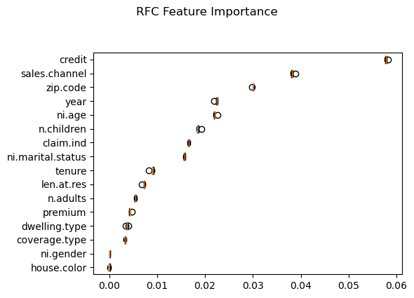

```python
# feature importance

result = permutation_importance(RFC, X_test, y_test, n_repeats=5, random_state=42)
perm_sorted_idx = result.importances_mean.argsort()

tree_importance_sorted_idx = np.argsort(RFC.feature_importances_)
tree_indices = np.arange(0, len(RFC.feature_importances_)) + 0.5

fig, ax1 = plt.subplots(1, 1, figsize=(6, 4))
ax1.boxplot(result.importances[perm_sorted_idx].T, vert=False,
            labels=X_sampled.columns[perm_sorted_idx])
fig.suptitle('RFC Feature Importance', y=1.05)
fig.tight_layout()
plt.show()
```

These are the top 5 Features that we found using permutation_importance

1. credit
2. sales.channel
3. zip.code
4. year
5. ni.age